# LPS Tier 2 — binary-path correctness gates: E2.14 (separation robustness) and E2.12 (selection-metric consistency)

**Report build:** 2026-06-11 17:35:50 EDT  
**Result generation:** 2026-06-11 17:35:50 EDT (UTC 2026-06-11T21:35:50Z)  
**Source commit:** `550d7e862edd` (branch `codex/geosmooth-t2-binary-hygiene`)  
**Report source (repo-relative):** `dev/methods/lps/reports/tier2/binary_hygiene/2026-06-11/`  
`scripts/lps_tier2_binary_hygiene_report.Rmd`  
**Input manifest:** `inputs/tier2_report_inputs_manifest.txt`  
**Bundle cross-check:** ok vs audit_artifacts/tier2_20260611T210313Z: e2_12a max |diff| = 4.441e-16; e2_14 traces max |diff| = 1.421e-14

All numbers shown are read from precomputed, committed CSV artifacts — the report-specific inputs in `inputs/` beside this report (regenerated deterministically by the adjacent `scripts/export_tier2_report_inputs.R` from the gated fixture constructors) and the gate/study evidence at the package-level `reports/` directory; this report did not rerun the experiments. The acceptance evidence proper lives in the execution bundles `audit_artifacts/tier2_20260611T075822Z` (E2.14, commit `75c1788`) and `audit_artifacts/tier2_20260611T084642Z` (E2.12 + E2.14 rerun, commit `3eaf9cf`), whose regenerated aggregates the input manifest cross-checks.

# Purpose

`fit.lps()` fits local weighted polynomial regression in local charts and selects its configuration (support size, polynomial degree, kernel) by cross-validation. Its binary path has two modes: `bernoulli` (local least squares on 0/1 labels; deployed probabilities are the predictions clipped to $[0,1]$) and `binomial` (local weighted logistic fits solved by iteratively reweighted least squares, IRLS; selection by cross-validated log loss).

This report documents the results of the two Tier-2 correctness gates that landed on branch `codex/geosmooth-t2-binary-hygiene`:

1. **E2.14 — separation robustness.** Is the local logistic IRLS monotone and bounded on (near-)separable supports, and does *exact* separation end in a documented, telemetered fallback rather than an unbounded loop or `NaN`? The fix under test is deviance **step-halving** inside the IRLS loop.
2. **E2.12 — selection-metric consistency and log-loss clipping.**
   1. Does bernoulli-mode selection score the **deployed** (clipped) metric rather than raw, unclipped predictions — and can the difference change which candidate is selected? (b) Is the log-loss probability truncation pinned at $10^{-6}$, and what instability did the previous $10^{-15}$ truncation permit? A companion **study** (reported, not gated) asks whether the selected candidate is stable across truncation levels $\{10^{-6}, 10^{-3}\}$.

Both gates are deterministic `testthat` batteries on constructed fixtures (no replication), so all results below are single realized values; no uncertainty intervals apply. The committed gates, both passing on the committed tree alongside the full Tier-0 battery inside the bundles named above, are:

- `tests/testthat/test-lps-binary-separation.R` (E2.14, 43 assertions);
- `tests/testthat/test-lps-binary-metric-consistency.R` (E2.12, 43 assertions including the audit-required backend-resolution coverage).

# E2.14 — the constructed separation fixtures

A local logistic solve receives a small neighborhood: 1-D local coordinates $z_i$ centered at the evaluation point, labels $y_i \in \{0,1\}$, and gaussian kernel weights $w_i$ that decay with $|z_i|$. The gate uses one support shape in two label configurations (the frozen plan’s DGP: $y = \mathbf{1}\{z>0\}$, optionally one flipped label, weights from the gaussian kernel):

The flip *position* is load-bearing: flipping an edge-of-cluster point produces the plain-Newton overshoot shown in Figure 2, while a mid-cluster flip leaves plain Newton monotone and would make the fix undetectable.

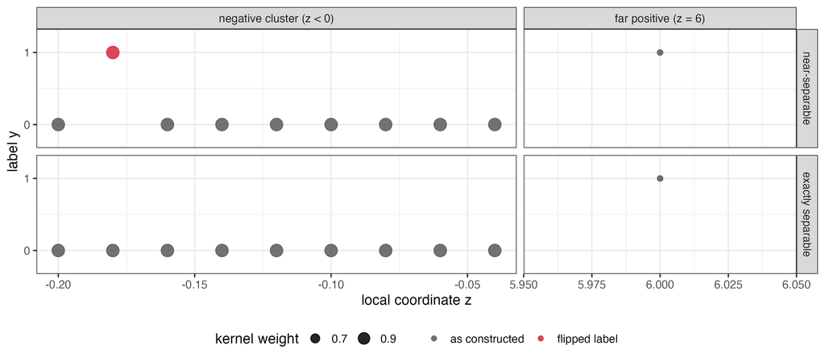

**Figure 1.** The E2.14 fixture in its two label configurations (rows: near-separable = one flipped label; exactly separable = no flip). The x-axis is split (columns, independent scales) because the far positive at $z = 6$ would otherwise compress the negative cluster into a single blot. Point size encodes the gaussian kernel weight: cluster points carry weight $\approx 1.0$, the far positive $\approx 0.61$. The red point in the top row is the single flipped label at $z = -0.18$ — a high-weight, wrong-side observation. Removing the flip (bottom row) makes the support exactly separable.

# E2.14 — deviance trajectories: plain Newton vs step-halving

The solver minimizes the weighted binomial deviance

$$D(\beta) \;=\; -2 \sum_i w_i \Big( y_i \log \mu_i(\beta)
+ (1-y_i)\log\big(1-\mu_i(\beta)\big) \Big),
\qquad
\mu_i(\beta) = \operatorname{expit}\!\big(\tilde\eta_i\big),$$

where $\tilde\eta_i$ is the linear predictor $\eta_i = x_i^\top\beta$ clamped to $[-35, 35]$ (the same clamp the IRLS update uses, which keeps $D$ finite for every finite iterate). Plain IRLS accepts every Newton update unconditionally. The E2.14 fix accepts a candidate $\beta_{\text{new}}$ only if $D(\beta_{\text{new}}) \le D(\beta_{\text{cur}}) + 10^{-8}$, halving the step toward $\beta_{\text{cur}}$ up to 30 times otherwise; an exhausted halving budget ends the solve as non-convergent. The gate asserts on the whole recorded trajectory, not only its endpoint, so oscillation cannot hide.

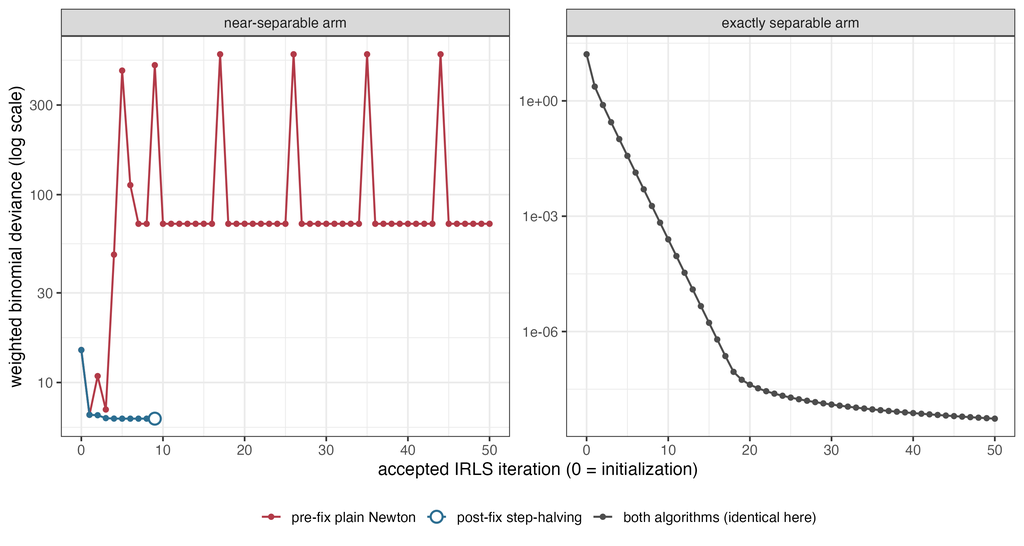

The realized endpoint quantities behind Figure 2:

Table 1. Post-fix solver summary per fixture arm. Columns: solver status string; whether the coefficient-step criterion (1e-7) was met within the 50-iteration cap; accepted iterations; total step halvings; the largest per-step deviance increase along the accepted trajectory (the gate requires it below 1e-8); the fitted center probability (‘–’ = no converged fit is returned; the fallback layer supplies the prediction, Table 2).

| arm | status | converged | iterations | step halvings | max dev. increase | p-hat (center) |
| --- | --- | --- | --- | --- | --- | --- |
| near.separable | ok | TRUE | 9 | 1 | 1.78e-15 | 0.1247 |
| exactly.separable | not_converged | FALSE | 50 | 0 | -1.58e-10 | – |

On non-convergence the fitting layer falls back deterministically and records it: under `unstable.action = "mean"` the prediction is the local weighted event rate $\bar y_w = \sum_i w_i y_i / \sum_i w_i$; under `unstable.action = "na"` it is `NA` (the sanctioned guarded output). The exactly separable arm exercises both paths:

Table 2. Fallback behavior and telemetry on the exactly separable arm (one solve attempt each). ‘returned value’ is the fitted probability the caller receives: the weighted event rate 0.063151 under “mean”, NA under “na”. The last four columns are the recorded telemetry counters (logistic.diagnostics): every fallback is counted, split into event-rate substitutions and NA returns. No NaN and no unbounded loop occurs.

| unstable.action | returned value | attempted | converged | fallback | event-rate fallback | NA failure |
| --- | --- | --- | --- | --- | --- | --- |
| mean | 0.063151 | 1 | 0 | 1 | 1 | 0 |
| na | NA | 1 | 0 | 1 | 0 | 1 |

E2.14 also pins that nothing changed where nothing needed to change: when every full Newton step already satisfies the deviance slack, the halving check accepts the identical iterate, so well-behaved solves are numerically identical to the pre-change solver (asserted in the gate against an independent plain-IRLS replication, and corroborated by the Tier-0 E0.6 battery statistics being bit-identical to the unmodified base commit).

# E2.12 — the constructed G6 fixture

Both E2.12 sub-items use the plan’s binary-surface DGP **G6** with one named override: a *sharp* log-odds cliff in place of the default smooth surface,

$$\eta(x) = 6\,\tanh(15\,x_1), \qquad
p(x) =
\min\!\big(\max(\operatorname{expit}(\eta(x)),\,0.05),\,0.95\big),
\qquad y \sim \mathrm{Bernoulli}(p),$$

on $x \in [-1,1]^2$ with $n = 400$ (prevalence target $0.5$ by symmetry; the $[0.05, 0.95]$ probability clamp is part of the G6 construction). The cliff at $x_1 = 0$ is what forces flexible local fits to overshoot $[0,1]$ on the raw scale — the behavior sub-item (a) needs. Sub-item (b) uses a second draw (seed 7001) of the same surface with one label deliberately flipped, fit in `binomial` mode.

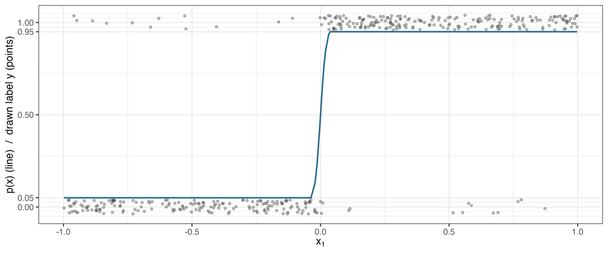

# E2.12(a) — selection scores the deployed clipped metric

For a candidate configuration $j$ with out-of-fold (cross-validation) predictions $\hat p_{ij}$, the two scores at issue are

$$\text{raw Brier}_j = \frac{1}{n}\sum_i \big(y_i - \hat p_{ij}\big)^2,
\qquad
\text{deployed Brier}_j = \frac{1}{n}\sum_i
\big(y_i - \operatorname{clip}_{[0,1]}(\hat p_{ij})\big)^2,$$

where $\operatorname{clip}_{[0,1]}$ is exactly the clamp applied to the probabilities the fitted model actually deploys (`fitted.values`, `predict()`). Pre-fix, bernoulli selection minimized the raw score while deployment clipped — a train/deploy metric mismatch. Post-fix, the selection column `cv.brier.observed` *is* the deployed score (with `Inf` for any candidate having a non-finite prediction, preserving the old `NA`-handling semantics).

Fit-status accounting for this fixture: all $4 \times 400 = 1600$ out-of-fold predictions are finite (no `NA` candidates, nothing excluded); 263 of them (16.4%) fall outside $[0,1]$, concentrated in the two degree-2 candidates — the clip is doing real work.

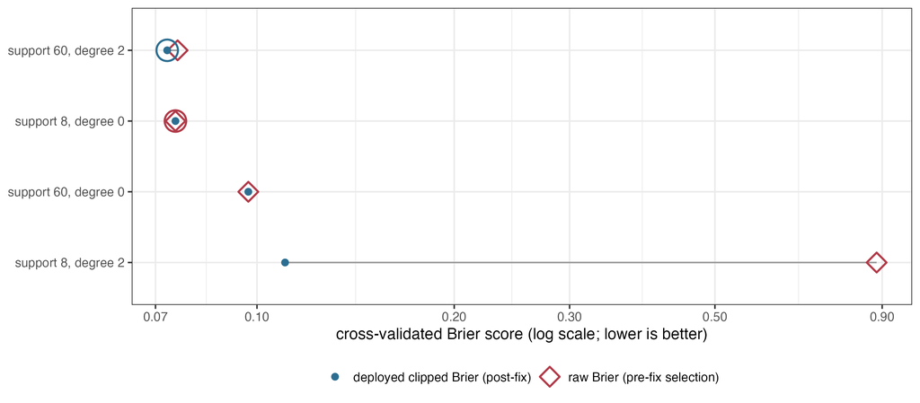

**Figure 4.** Per-candidate selection scores on the E2.12(a) fixture under the two metrics (one row per candidate; open red diamonds = raw Brier, filled blue dots = deployed clipped Brier; grey segments connect a candidate’s two scores; log x-axis; large circles mark each metric’s minimizer). Where a candidate’s predictions never leave $[0,1]$ the two scores coincide exactly and the blue dot sits inside the red diamond. Clipping therefore moves nothing for the in-range candidates but rescues the degree-2 candidates whose raw predictions overshoot — most dramatically (support 8, degree 2), whose score falls from $0.883$ to $0.110$. The two metrics disagree on the winner: the raw score (the pre-fix rule) picks (support 8, degree 0) while the deployed score picks (support 60, degree 2), with cross-candidate margins of $5.8 \times 10^{-4}$ (raw) and $2.1 \times 10^{-3}$ (deployed) — both more than $100\times$ the contract’s $10^{-6}$ comparison tolerance, so the flip is real rather than a tie. The post-fix fit deploys the clipped winner.

Table 3. The four candidates on the E2.12(a) fixture. ‘raw Brier’ is the mean squared error of the unclipped out-of-fold predictions (the pre-fix selection score); ‘deployed Brier’ is the same on [0,1]-clipped predictions and is the post-fix selection column cv.brier.observed; the two count columns give each candidate’s out-of-fold predictions outside [0,1] (of 400); ‘selected’ marks the candidate the post-fix fit returns. The gate additionally verifies the selection column equals the deployed metric recomputed from the stored CV predictions (max residual 1.4e-17, contract tolerance 1e-6).

[output not shown]

# E2.12(b) — the log-loss clip: one point owned the score

Binomial-mode selection minimizes the cross-validated log loss with probability truncation $\varepsilon$:

$$\mathrm{LL}_\varepsilon(j) = -\frac{1}{n}\sum_i \Big(
y_i \log \operatorname{clip}_{[\varepsilon,\,1-\varepsilon]}(\hat
p_{ij})
+
(1-y_i)\log\big(1-\operatorname{clip}_{[\varepsilon,\,1-\varepsilon]}(\hat
p_{ij})\big)\Big).$$

A confidently wrong held-out point ($\hat p \approx 0$, $y = 1$) contributes $-\log\varepsilon$ — $34.54$ at the previous $\varepsilon = 10^{-15}$ versus $13.82$ at the pinned $\varepsilon = 10^{-6}$. On the (b) fixture the deliberately flipped observation’s out-of-fold prediction is exactly $0$ under both candidates: its 60-point neighborhoods are all-zero, so the local logistic solve lands in the event-rate fallback, whose weighted mean of zeros is $0$.

Fit-status accounting: the binomial cross-validation ran 800 local logistic solves (400 points $\times$ 2 candidates); 785 converged (98.1%) and 15 (1.9%) took the telemetered event-rate fallback — among them all solves for the flipped point. All 800 predictions are finite; none is excluded from any summary.

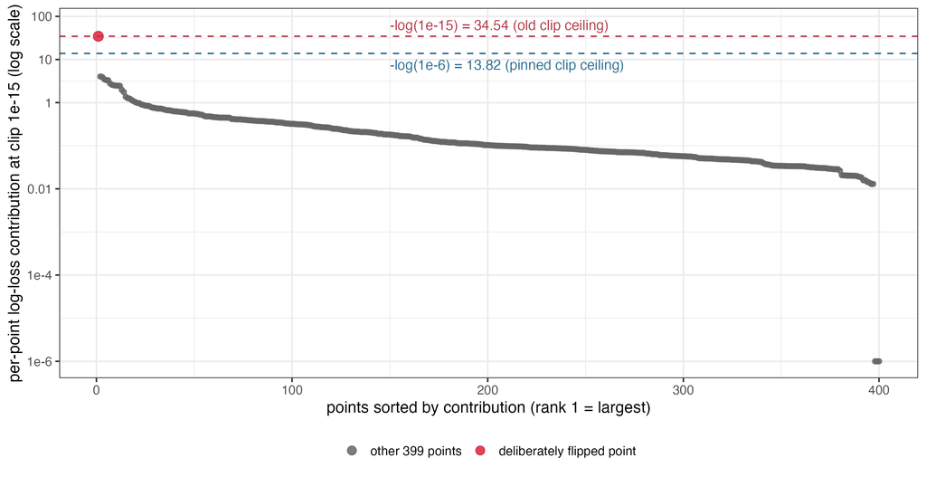

**Figure 5.** Per-point log-loss contributions at the old truncation $\varepsilon = 10^{-15}$ for the selected candidate (support 60, degree 0), sorted in decreasing order (log y-axis; the 3 points with contributions below $10^{-6}$ are drawn at the $10^{-6}$ display floor). The deliberately flipped point (red, rank 1) contributes $-\log(10^{-15}) = 34.54$ — $8.6\times$ the largest other contribution ($4.03$) — and is the *only* point whose prediction lies outside $[10^{-6}, 1-10^{-6}]$, so it accounts for 100% of the score change when the truncation moves from $10^{-15}$ to $10^{-6}$ (a $0.052$ shift of the mean score, both candidates). Pinning $\varepsilon = 10^{-6}$ caps that single point’s leverage at the blue ceiling; the dashed lines mark the two ceilings.

Table 4. Per-candidate log-loss scores at the three truncation levels and the single-point dominance accounting. ‘flip share’ is the fraction of the LL(1e-15) - LL(1e-6) score change attributable to the flipped observation (1.0 = all of it); ‘flip contrib’ and ‘max other’ compare its per-point contribution at clip 1e-15 with the largest contribution among the other 399 points. LL(1e-6) equals the deployed selection column cv.logloss.observed exactly (residual 0).

| support | degree | LL(1e-15) | LL(1e-6) | LL(1e-3) | flip share | flip contrib | max other |
| --- | --- | --- | --- | --- | --- | --- | --- |
| 60 | 0 | 0.3771 | 0.3253 | 0.3080 | 1.0000 | 34.5388 | 4.0318 |
| 60 | 1 | 0.3793 | 0.3275 | 0.2974 | 1.0000 | 34.5388 | 12.0363 |

# E2.12 study — selection stability across truncation levels

The contract treats cross-clip selection stability as a **study** — its verdict is recorded, never gated, because near-tied candidates may legitimately reselect when the truncation changes. The predeclared rule: the selection is *stable* iff the log-loss minimizer at $\varepsilon = 10^{-6}$ equals the minimizer at $\varepsilon = 10^{-3}$, computed from the same out-of-fold predictions.

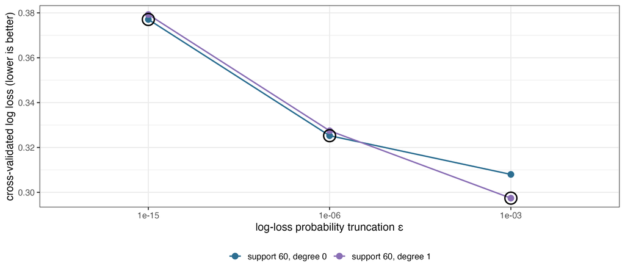

**Figure 6.** Cross-validated log loss of the two E2.12(b) candidates as a function of the truncation level $\varepsilon$ (black circles mark the minimizer at each level). The selection is identical at $10^{-15}$ and at the pinned $10^{-6}$ (support 60, degree 0; margin $0.0022$) and *reselects* at $10^{-3}$ (support 60, degree 1; margin $0.0106$): the coarser truncation caps the flipped point’s penalty at $-\log(10^{-3}) = 6.9$ and also truncates the degree-1 candidate’s confident near-miss predictions, enough to move a $0.002$-wide near-tie. The recorded study verdict is therefore **“not stable (near-tie reselected; recorded, not gated)”** (verdict CSV) — precisely the legitimate-reselection case the contract anticipated when it declined to gate this comparison.

# Results summary and discussion

**E2.12(a) — positive.** The train/deploy metric mismatch is not hypothetical: on a sharp G6 surface the raw and deployed Brier scores rank the candidates differently (margins $> 100\times$ the comparison tolerance), and the pre-fix rule would have deployed the wrong candidate (support 8, degree 0) over the one that is actually better as deployed (support 60, degree 2). Post-fix, the selection column *is* the deployed clipped metric (recomputed-equality residual $1.4\times10^{-17}$), and the invariant is unconditional over legal bernoulli configurations: per the independent audit’s required fix (`audits/tier2_audit_2026-06-11.md`), bernoulli now always uses the R cross-validation path — `backend = "auto"` resolves to `"R"` exactly as for `binomial`, and an explicit C++ backend is an error — because the C++ CV kernels return only the aggregate raw RMSE and cannot score the deployed metric. The gate pins this resolution and a gaussian control confirming the C++ fast path remains available outside the binary families.

**E2.12(b) — positive, with the instability precisely localized.** At the old $10^{-15}$ truncation, one deliberately confident-wrong held-out point contributes $34.54$ — $8.6\times$ any other point — and owns 100% of the score’s sensitivity to the truncation level. The pin at $10^{-6}$ caps exactly that leverage. The cross-clip study honestly records that a $0.002$-wide near-tie reselects at $10^{-3}$: cross-clip invariance is a robustness goal, not a correctness criterion, and this fixture sits on the expected boundary.

**Failure modes and residual limits.** Nothing in these results validates the gates against adversarial mutation — that is the auditor’s mutation-qualification step, deliberately not run by the implementer. All numbers come from one machine/BLAS (macOS arm64, vecLib); the decisive margins ($\ge 5.8\times10^{-4}$) sit far above plausible floating-point jitter, but no second platform was exercised. The pre-fix E2.14 trajectory is a committed replication of the pre-change update equations, not an execution of the deleted code. Both fixtures are single deterministic constructions (per the contract’s smoke/full sizing: “deterministic — no replication”), so no uncertainty intervals apply anywhere in this report.

# What we learned

- IRLS instability under near-separation is real but *geometrically selective*: it took an edge-of-cluster flipped label adjacent to a far same-class point to trigger it (a mid-cluster flip is benign). One step-halving is enough to recover a genuine fit that the pre-fix solver abandoned to a fallback — the fix improves fits, not just telemetry.
- The variance floor and $\pm 35$ linear-predictor clamp already prevented `NaN`; what they could not prevent was non-monotone oscillation, which is invisible at the endpoint and only assertable on the trajectory. Gating the *trajectory* was the right call.
- Metric mismatches between selection and deployment can flip model choice on realistic sharp-boundary binary surfaces — 16% of out-of-fold predictions leaving $[0,1]$ was enough. Selection now optimizes what is deployed.
- A $10^{-15}$ log-loss truncation converts a single all-zero-neighborhood fallback prediction into the dominant term of the selection score; a $10^{-6}$ pin bounds that single-point leverage while leaving every in-range contribution untouched.
- A near-tie ($\Delta \approx 0.002$) between candidates can legitimately reselect under truncation changes; recording this as a study verdict rather than gating it keeps the acceptance criteria honest.

# Appendix — reproducibility

All commands assume the package root of worktree `/Users/pgajer/current_projects/geosmooth-t2`, branch `codex/geosmooth-t2-binary-hygiene`.

**Report build:** 2026-06-11 17:35:50 EDT. **Result generation:** 2026-06-11 17:35:50 EDT (UTC 2026-06-11T21:35:50Z) at commit `550d7e862edd25c6d0092f267acfca67b88cfb20`; BLAS `libBLAS.dylib`; R version 4.5.2 (2025-10-31). Bundle cross-check at generation: ok vs audit_artifacts/tier2_20260611T210313Z: e2_12a max |diff| = 4.441e-16; e2_14 traces max |diff| = 1.421e-14.

Result artifacts consumed (committed; report-specific inputs under `inputs/` beside this report with SHA-256 in the input manifest; gate/study evidence at the package-level `reports/`):

- E2.14 inputs: `e2_14_fixture.csv`, `e2_14_deviance_traces.csv`,  
  `e2_14_solver_summary.csv`, `e2_14_fallback_telemetry.csv`;
- E2.12 inputs: `e2_12_fixture_a.csv`, `e2_12a_selection_metric.csv`,  
  `e2_12b_contributions.csv`, `e2_12b_clip_dominance.csv`,  
  `e2_12b_fit_accounting.csv`;
- gate/study evidence (`reports/`): `e2_14_prefix_newton_overshoot.csv`,  
  `e2_12_crossclip_scores.csv`, `e2_12_crossclip_stability_verdict.csv`.

Generation and rendering commands:

```bash
R="dev/methods/lps/reports/tier2/binary_hygiene/2026-06-11"

# 1. (re)generate every report-input CSV + manifest into $R/inputs/
#    (deterministic; the optional argument cross-checks against an
#    execution bundle):
Rscript "$R/scripts/export_tier2_report_inputs.R" \
  audit_artifacts/tier2_20260611T084642Z

# 2. pre-fix trajectory + cross-clip study artifacts (committed
#    gate/study evidence under reports/):
Rscript validation/e2_14_prefix_newton_overshoot.R
Rscript validation/e2_12_crossclip_stability_study.R

# 3. render this report, HTML + PDF (written into $R/):
Rscript "$R/scripts/render_lps_tier2_binary_hygiene_report.R"

# acceptance evidence proper (clean committed tree; auditor-facing):
EXECUTOR="<id>" bash scripts/ci/run_tier2_execution_artifact.sh
```

Seeds and determinism: the E2.14 fixtures are seed-free closed-form constructions; E2.12 uses `set.seed(2121)` (sub-item a) and `set.seed(7001)` with the label of observation 7 flipped (sub-item b); cross-validation folds are the explicit `foldid = rep(1:5, length.out = 400)` in all fits (never the internal `cv.seed`).

Related committed documents and machine-local evidence:

- gate test files: `test-lps-binary-separation.R`,  
  `test-lps-binary-metric-consistency.R`;
- implementer handoffs: `e2_14_implementer_handoff_2026-06-11.md`,  
  `e2_12_implementer_handoff_2026-06-11.md`;
- execution bundles (machine-local, gitignored): `audit_artifacts/tier2_20260611T075822Z` and  
  `audit_artifacts/tier2_20260611T084642Z`.